# Early Access

This course is available in early access. You can get it now with part of the final release’s content. The price will increase with the next release.

**We care about your feedback**! If you have doubts, get stuck, find a bug, or would like to suggest improvements, please leave a message under the corresponding lesson, or in the discussions tab on Mavenseed.

You can also [join our Discord community](https://discord.gg/CHYVgar) and use the *# courses-support* channel to reach us.

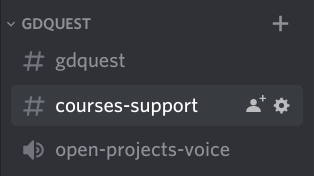

## Download the course files

On Mavenseed, you can download the course’s lessons to watch them offline. To do so, under any lesson, click on the text that says *X Course Files*. Doing so expands a section that lists available course downloads.

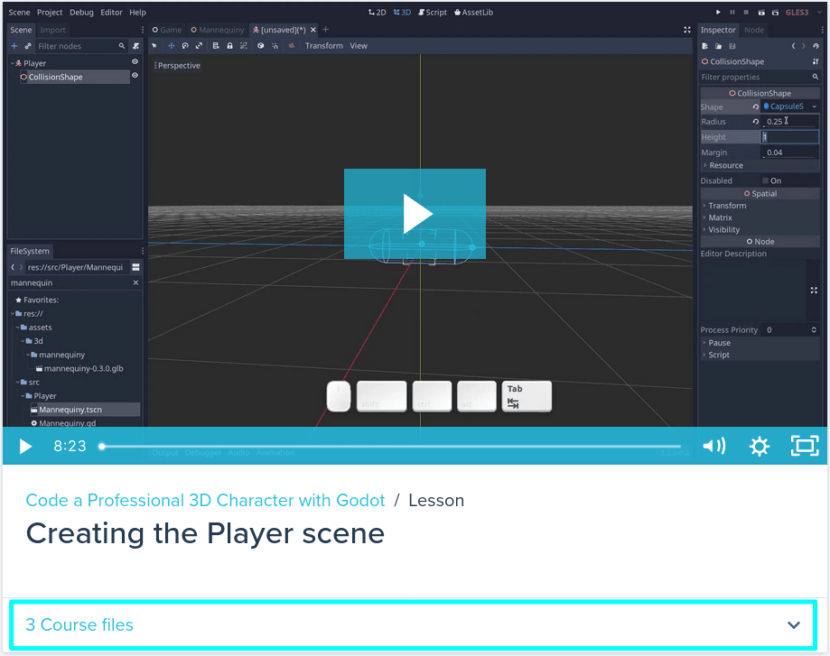

**Mavenseed currently does not support videos inside text lessons**. The platform’s developers are working on adding such a feature, but it’s not available yet.

To get videos inside lessons, you need to download the lessons using the method described above, and open the HTML documents.